# Процесс EM анализа

Ирина Голощапова

6 октября 2016 г.

# EM for Factor Contributions

1. *Основной вывод*.  
   Данные кажутся очень однородными - и визуально и содержательно.  
   По критерию BIC с огромным отрывом - для наиболее вариабельных ковариационных матриц - лидирует **единица как оптимальное число кластеров**.  
   Если мы позволяем формам кластеров быть различными - а именно - эллипсам быть наклонными (используем соответствующую ковариационную матрицу для выявления смеси гауссиан), то тогда наиболее эффективный вариант - это только один кластер. Все остальное - натяжки.
2. *Итоги для ограниченной ковариационной матрицы*.  
   Однако, если ограничить возможности ковариацинной матрицы так, что форма кластеров способна менять только объем (достаточно близко к k-means), то *оптимальным числом кластеров является 3*.  
   При этом графические результаты классификации опять же выглядят разделением однородной выборки.

## Ellipsoidal gaussian distributions

*Covariance matrices with variable volume, shape and orientation*

1. Оптимальное число кластеров c огромным отрывом по BIC - 1.

```
## ----------------------------------------------------
## Gaussian finite mixture model fitted by EM algorithm
## ----------------------------------------------------
##
## Mclust XXX (ellipsoidal multivariate normal) model with 1 component:
##
##  log.likelihood  n df      BIC      ICL
##        2544.593 63 27 4977.322 4977.322
##
## Clustering table:
##  1
## 63
```

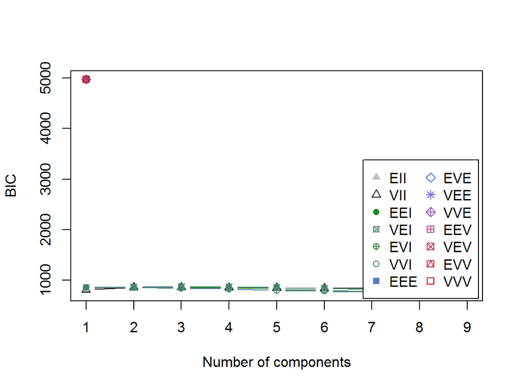

2. Визуально данные выглядят однородными и выбор одного кластера - адекватным.

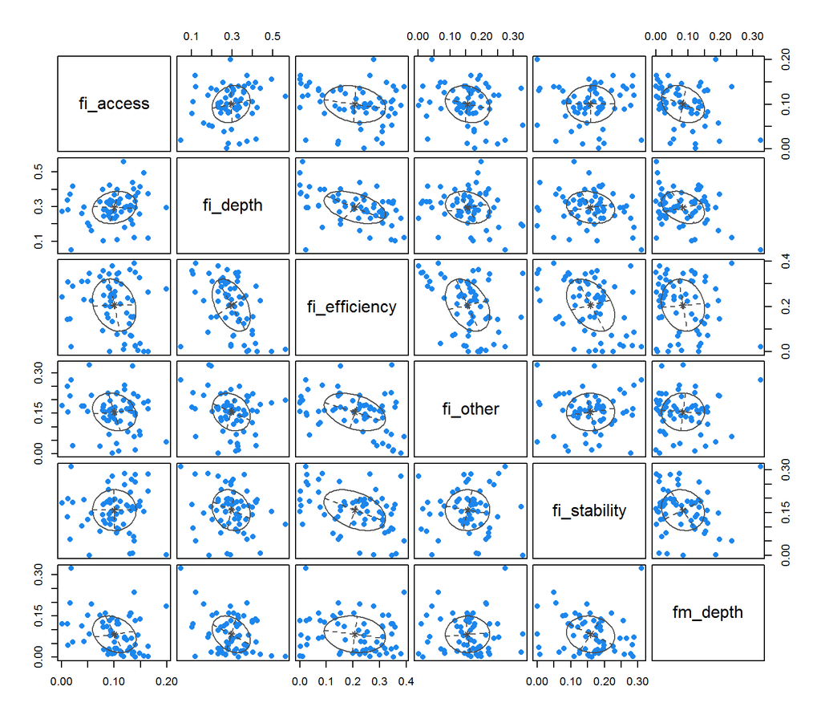

## Diagonal gaussian distributions

*Covariance matrices with coordinate axes orientation - only with variable volume*

1. Оптимальное число кластеров - 3.

```
## ----------------------------------------------------
## Gaussian finite mixture model fitted by EM algorithm
## ----------------------------------------------------
##
## Mclust VEI (diagonal, equal shape) model with 3 components:
##
## Prior: defaultPrior()
##
##  log.likelihood  n df     BIC     ICL
##        492.4199 63 28 868.832 862.598
##
## Clustering table:
##  1  2  3
## 24 24 15
```

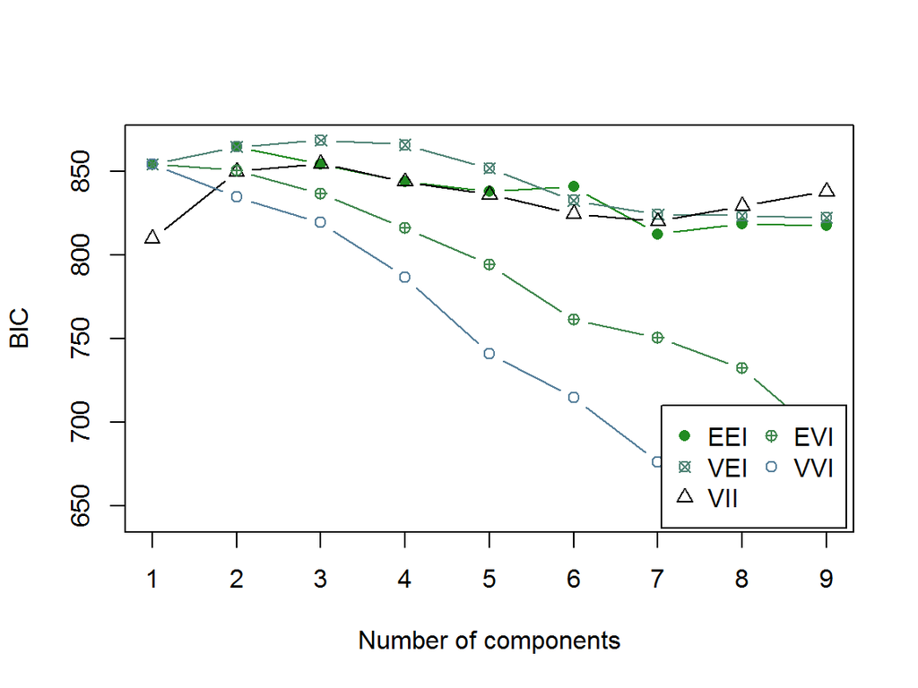

2. Визуально кластеры выглядят смешанными по большинству измерений - за исключением financial efficiency.

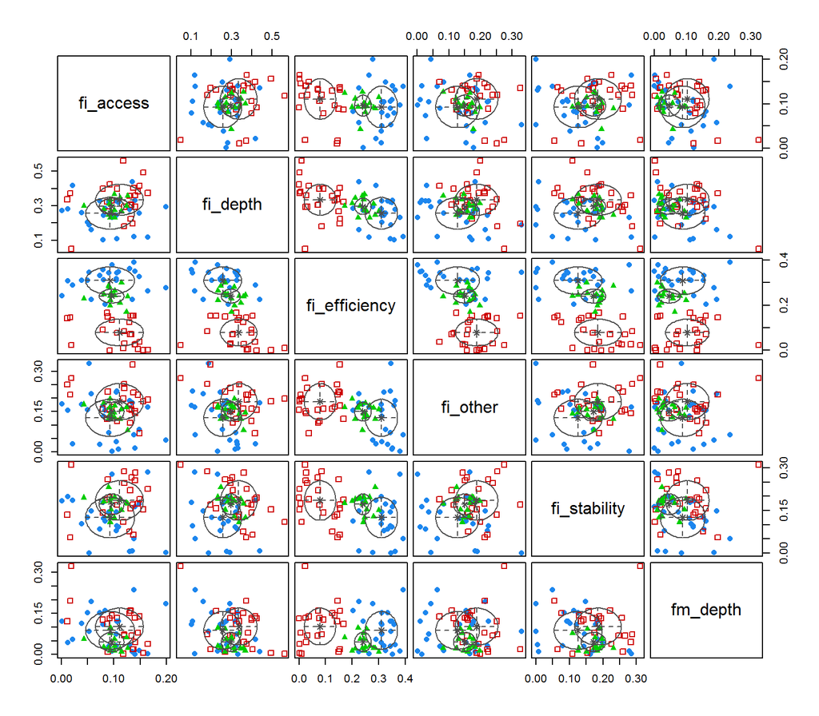

3. Большинство объектов анализа характеризуется высокой мерой неопределенности.

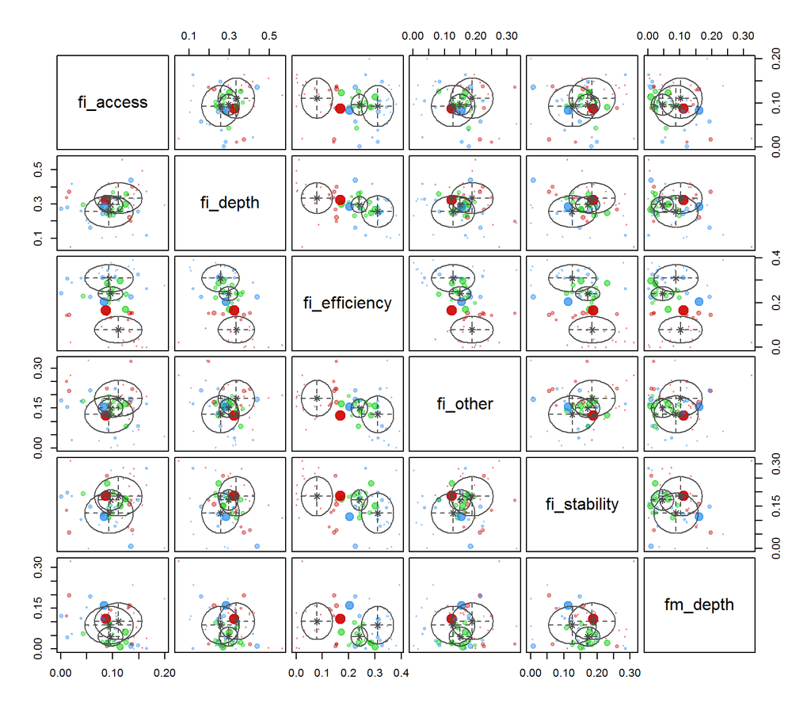

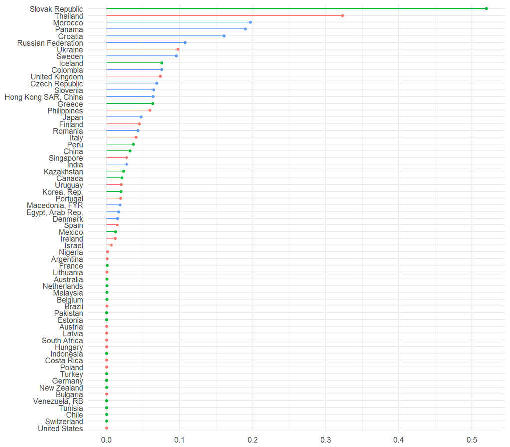

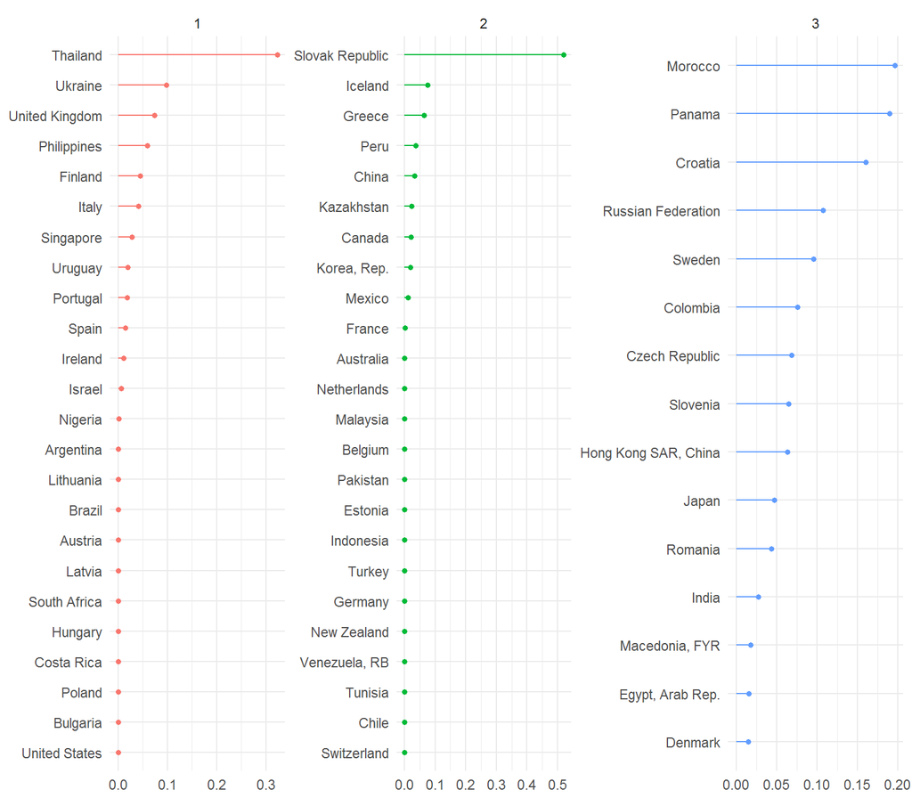

# EM for Factor Correlations with corrected signs

*Any gaussians*

1. Классический подход по критерию BIC сходится к оптимальному числу кластеров - 5.

```
## ----------------------------------------------------
## Gaussian finite mixture model fitted by EM algorithm
## ----------------------------------------------------
##
## Mclust VVI (diagonal, varying volume and shape) model with 5 components:
##
##  log.likelihood  n df       BIC       ICL
##       -159.2629 63 64 -583.6863 -584.9082
##
## Clustering table:
##  1  2  3  4  5
## 15 24 15  4  5
```

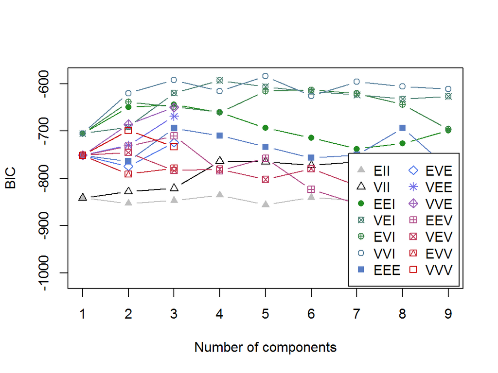

2. Визуально кластеры выглядят разнородными. Однако деление во многих срезах далеко не очевидно.

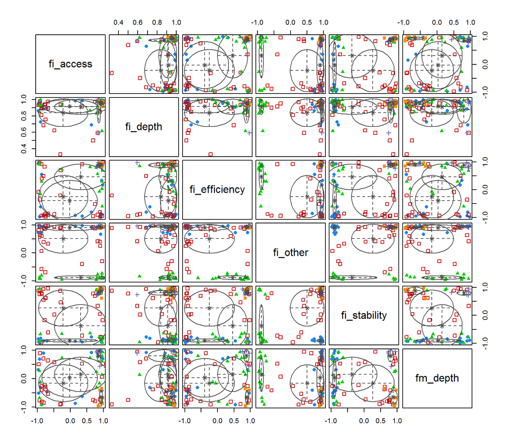

3. Намного меньшее число объектов анализа характеризуется высокой мерой неопределенности относительно случая с кластеризацией по факторным вкладам.

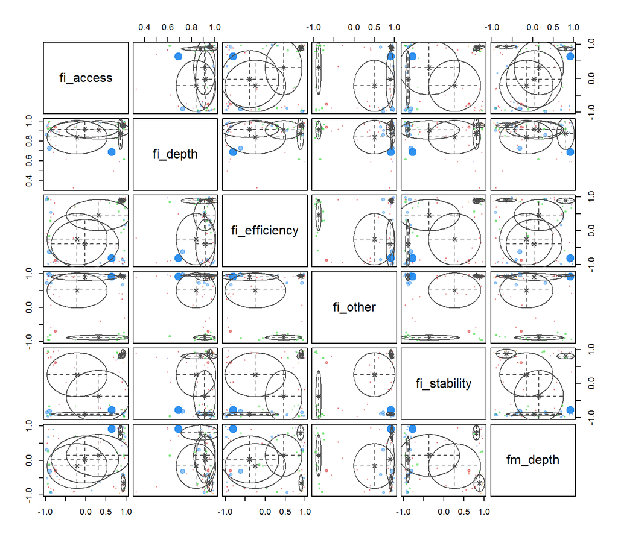

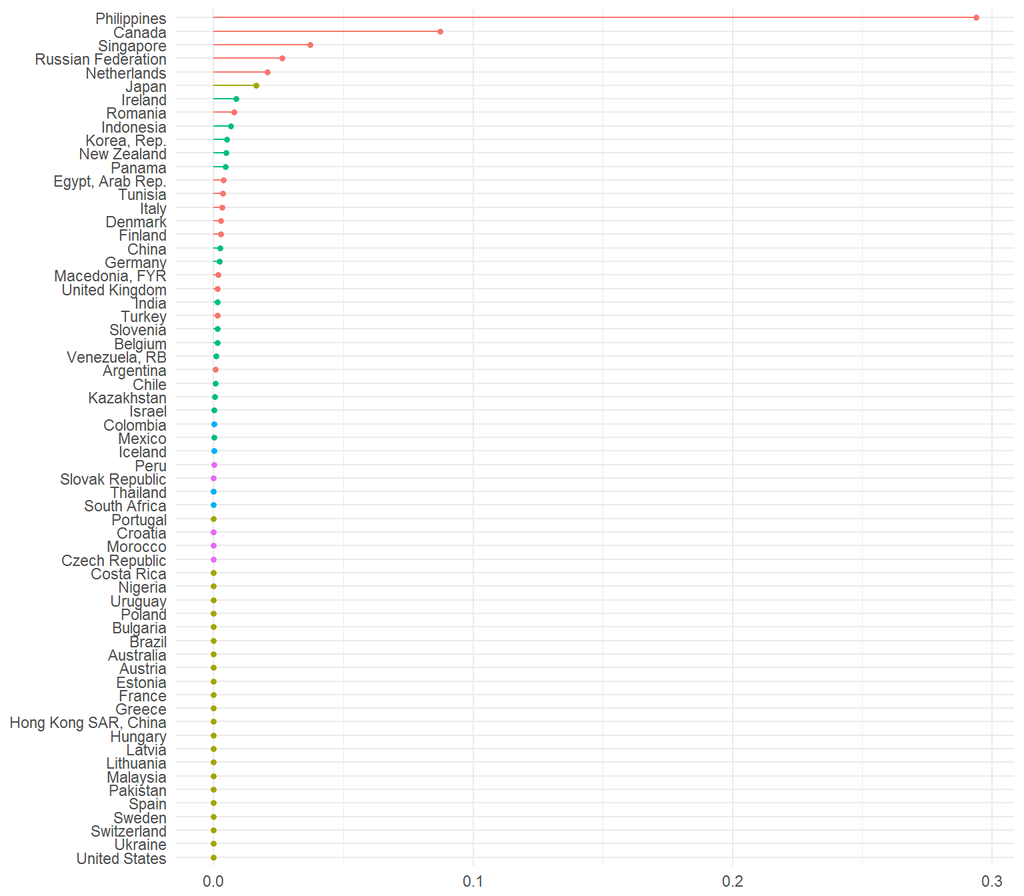

Интерпретируемы ли кластеры содержательно?

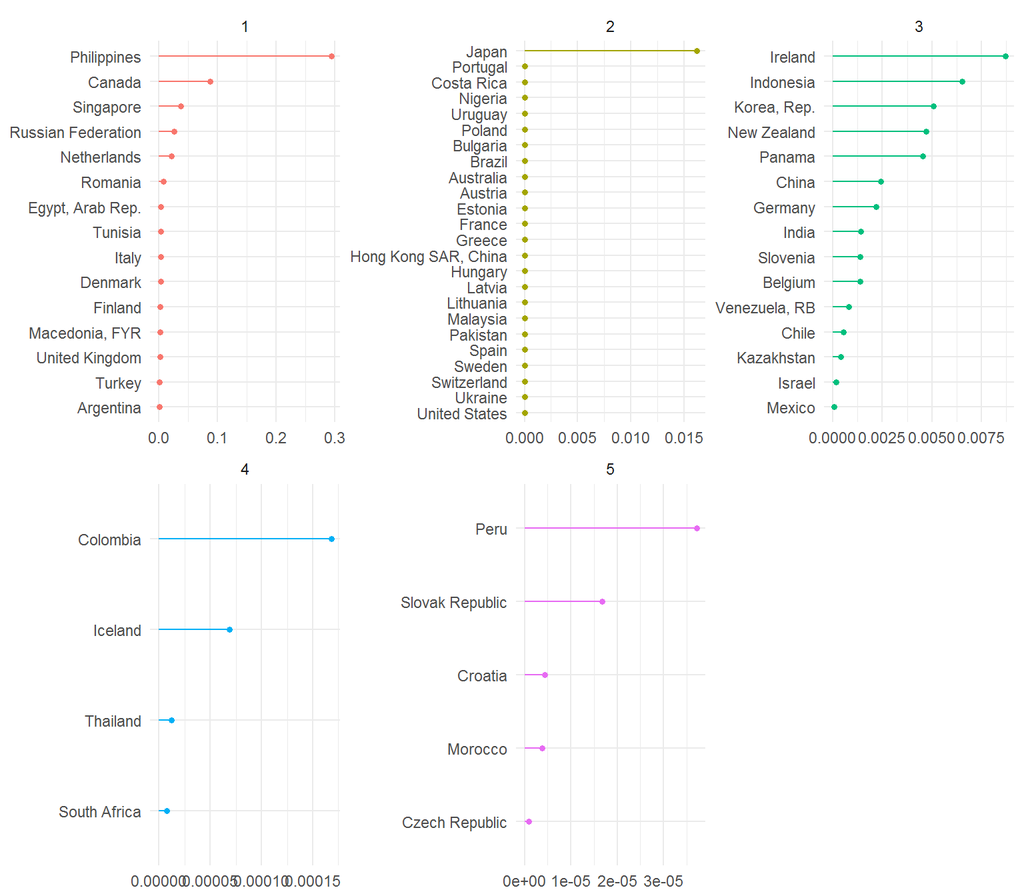

5. **Байесовский подход к EM приводит к 3 кластерам *c точно определенными кластером для России***.

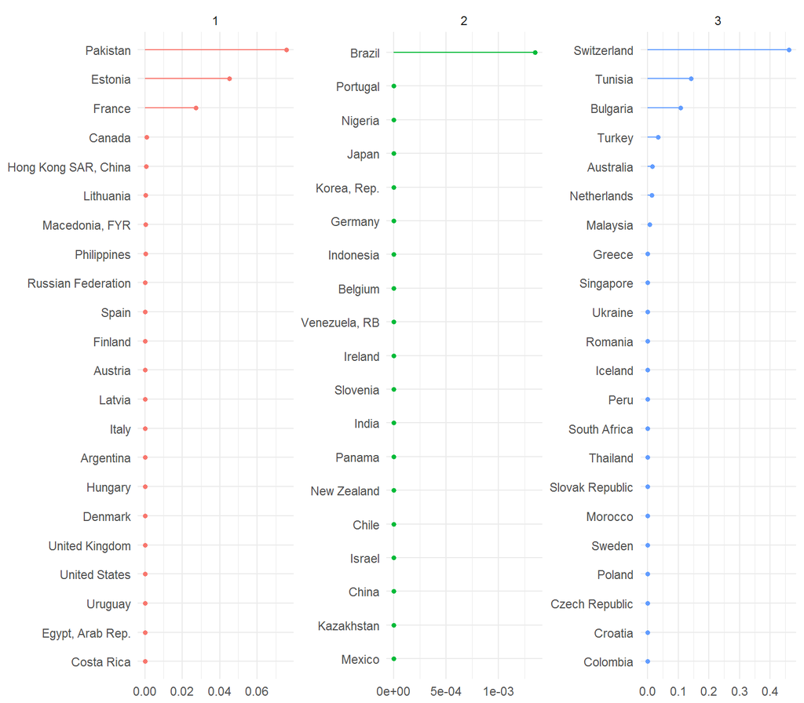

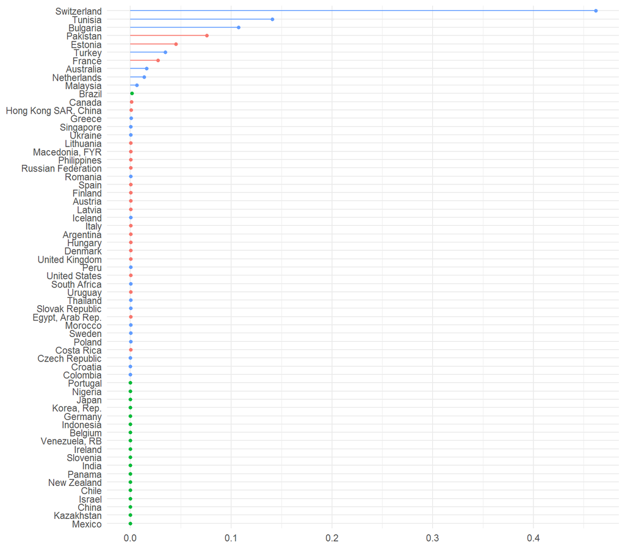

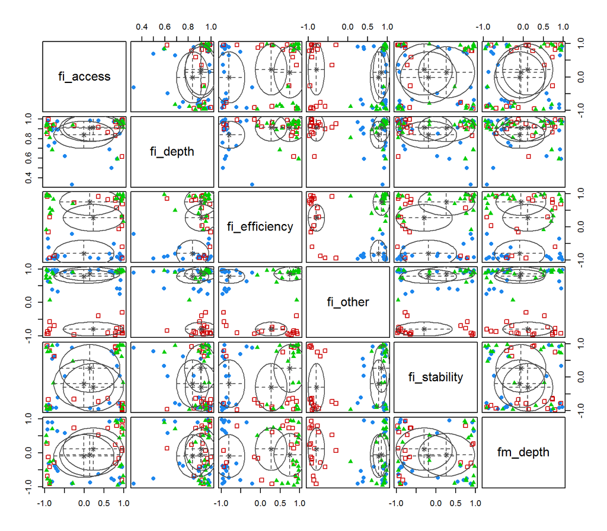

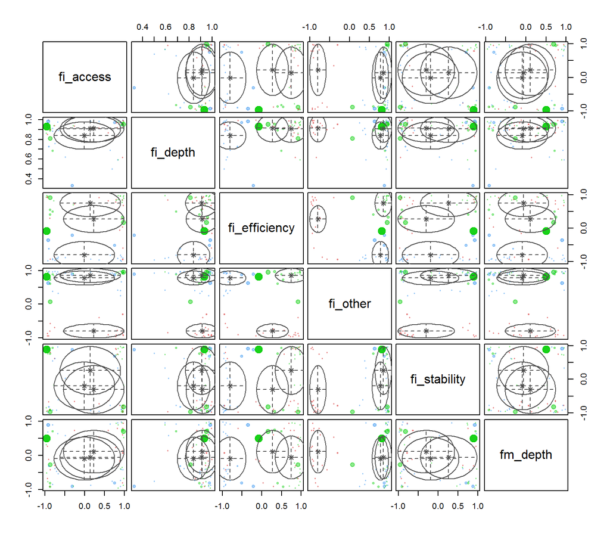

# EM for first principal components

*Any gaussians*

Методология предобработки *отличается* (подробнее - [здесь](http://irinagoloshchapova.github.io/Projects/CBR/PCA_imf)):

- Нормализация по индикаторам (без разреза по странам).
- Значения первых главных компонент усреднены за период 2004-2014 гг.
1. Классический подход по критерию BIC сходится к оптимальному числу кластеров - 6.  
   Но при этом получаются 2 странных кластера: 5 - Ирландия и Исландия, 6 - Гонконг.  
   (При этом Байесовский подход к EM сглаживает состав кластеров и достигает оптимума на 4 кластерах).

```
## ----------------------------------------------------
## Gaussian finite mixture model fitted by EM algorithm
## ----------------------------------------------------
##
## Mclust EEI (diagonal, equal volume and shape) model with 6 components:
##
##  log.likelihood  n df       BIC       ICL
##       -456.0077 63 47 -1106.743 -1109.301
##
## Clustering table:
##  1  2  3  4  5  6
## 17  8 18 17  2  1
```

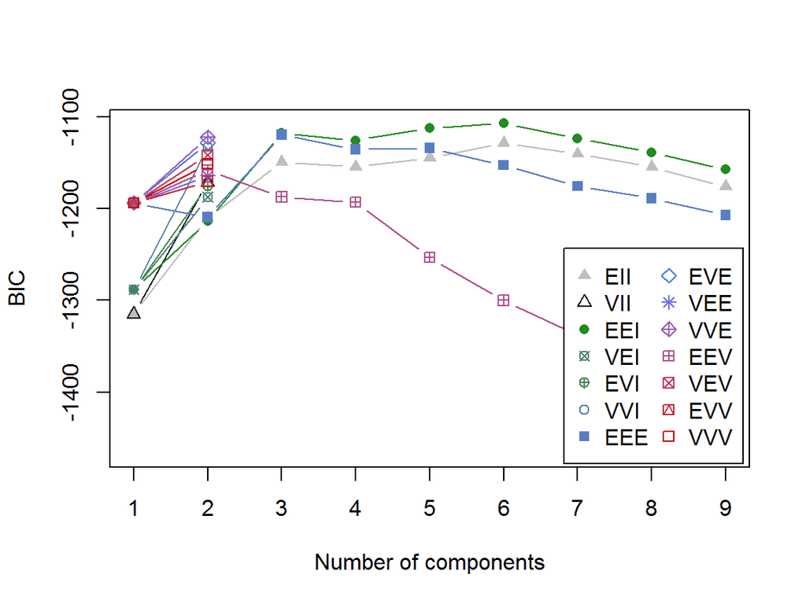

2. Визуально кластеры выглядят разнородными. Очень выделяется Гонконг.

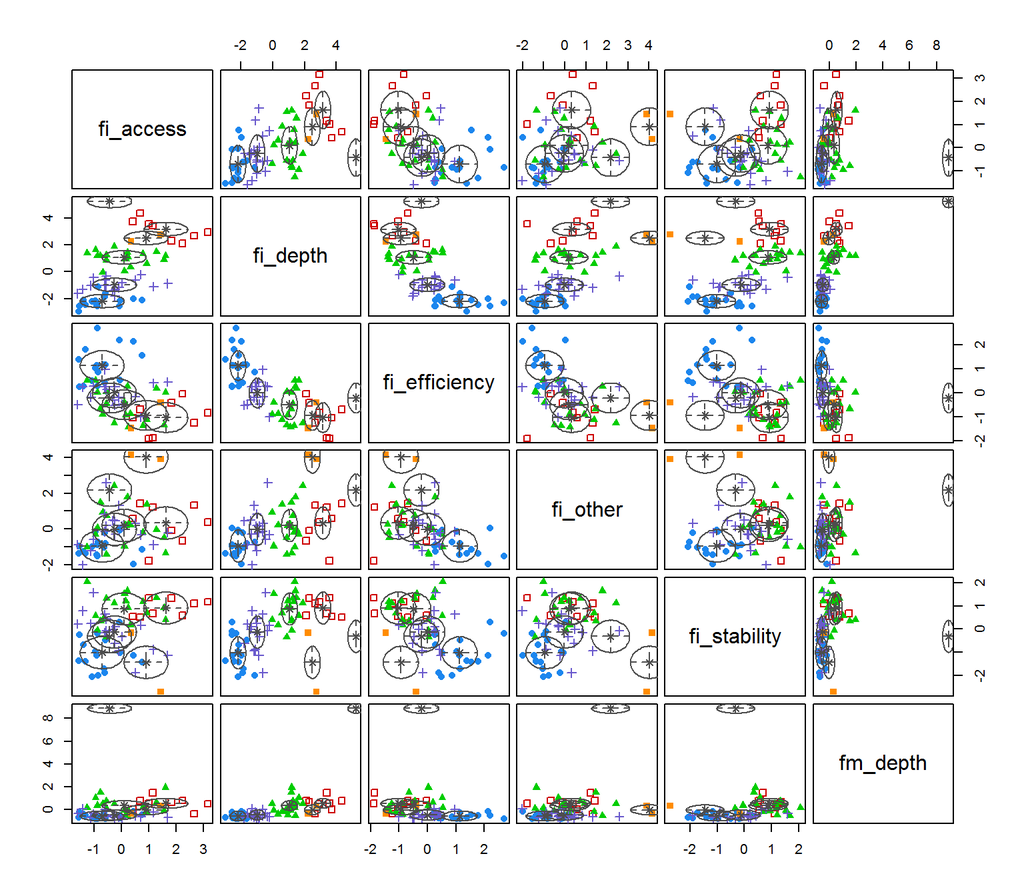

3. На границах кластеров присутствуют объекты с высокой неопределенностью.

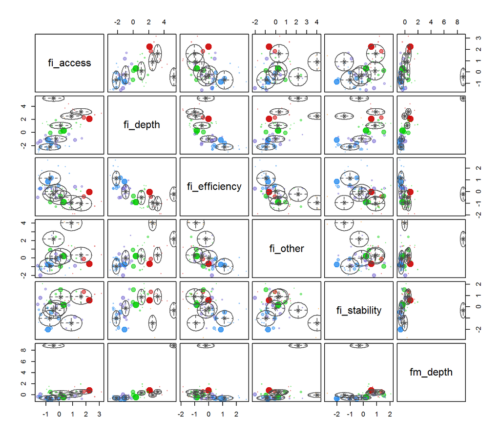

4. Страны, упорядоченные по неопределенности включения в “свой” кластер

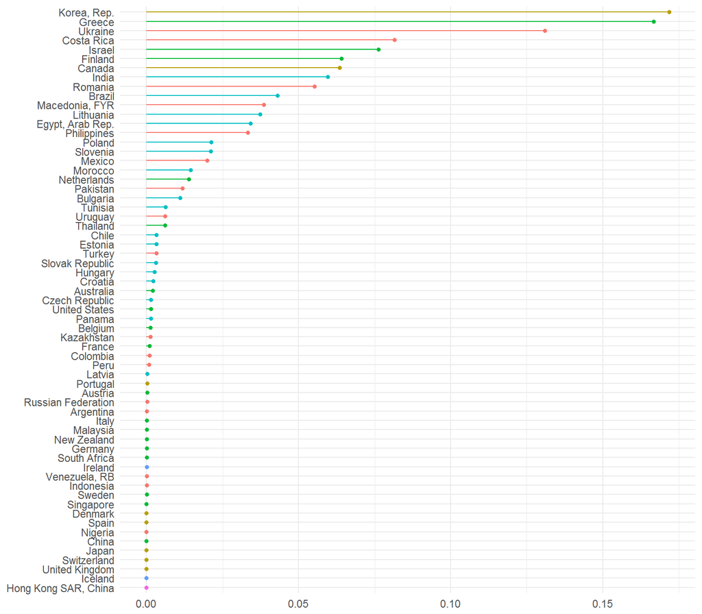

Состав кластеров

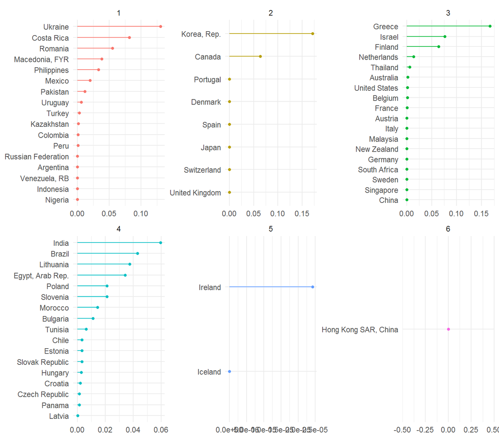

5. Байесовский подход к EM сглаживает состав кластеров и достигает оптимума на 4 кластерах.

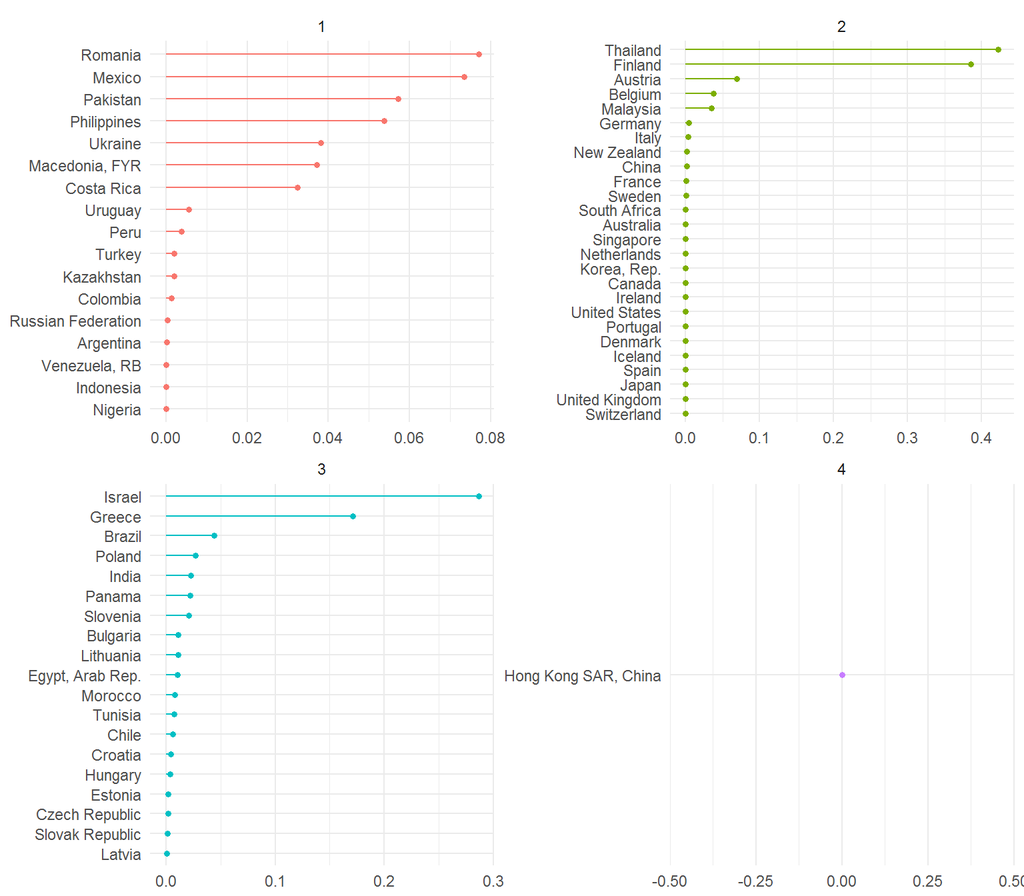

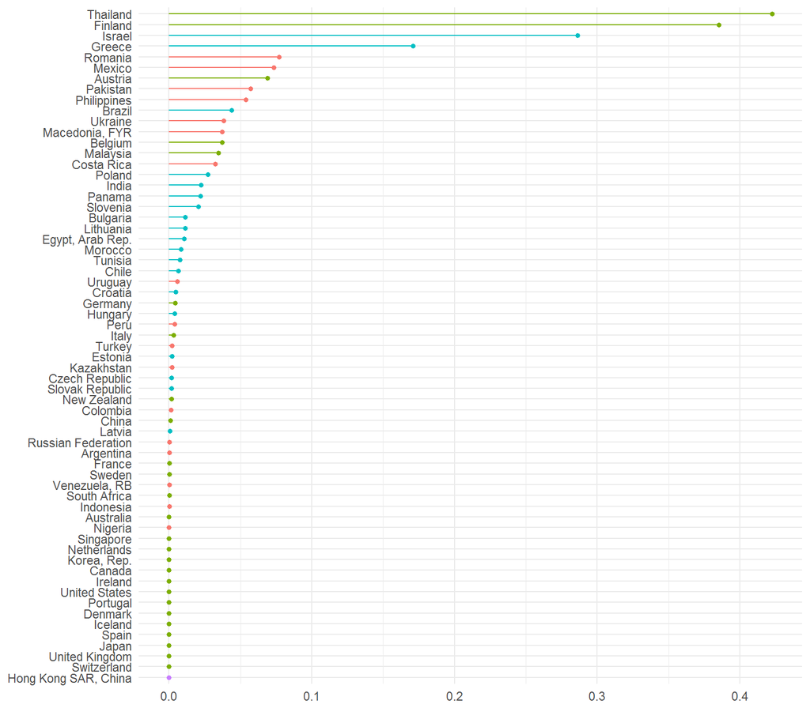

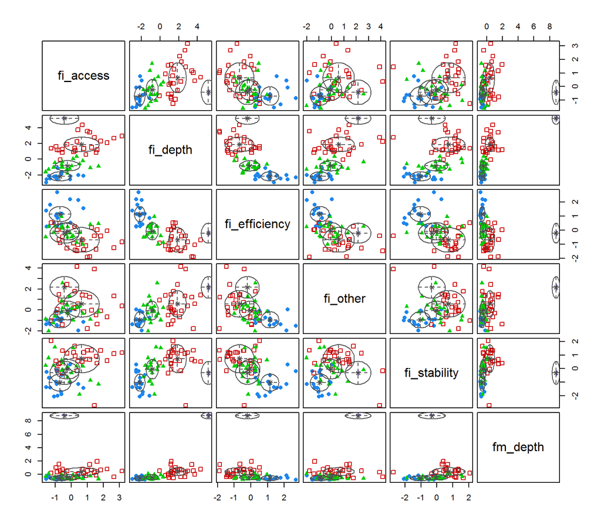

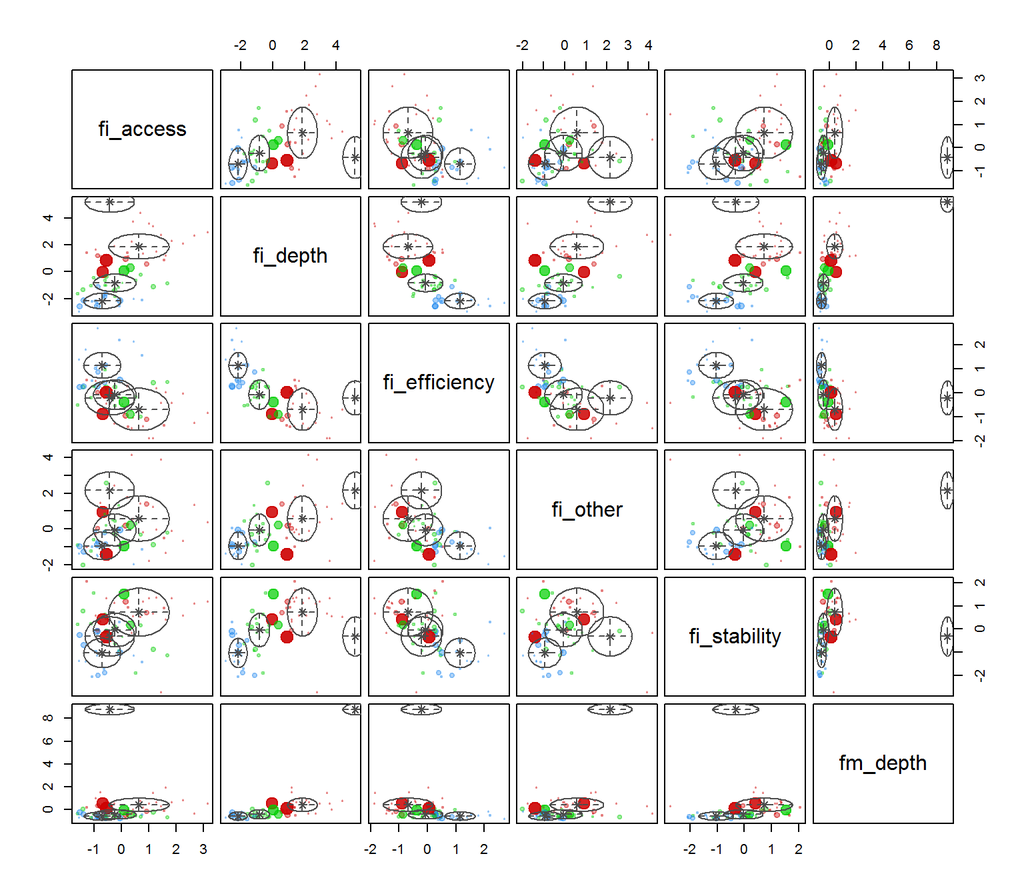

# Сравнение всех результатов EM: по факторным нагрузкам, по корреляциям, по ГК

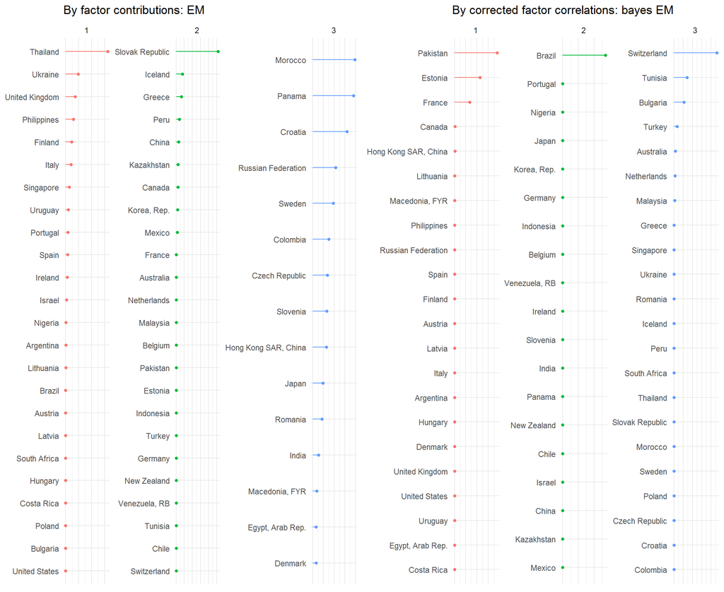

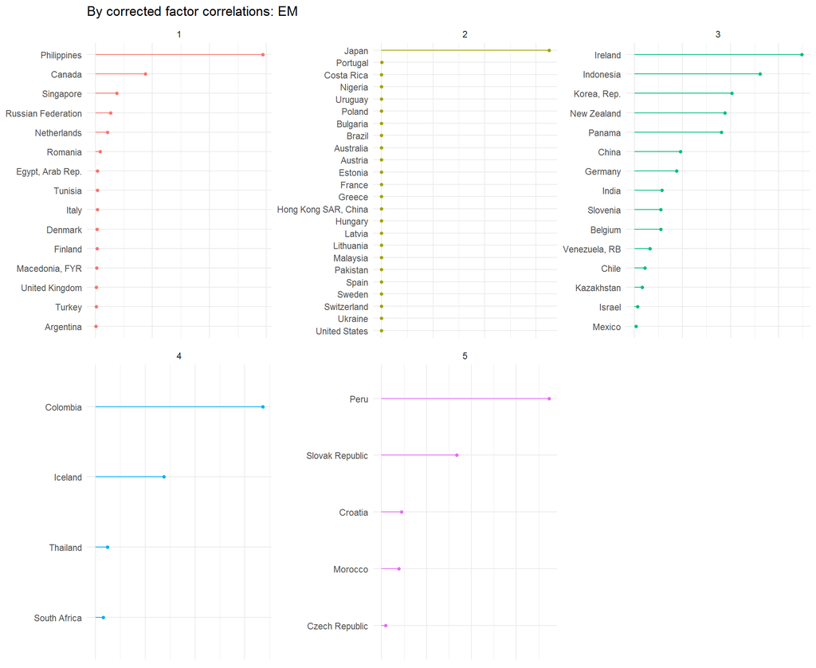

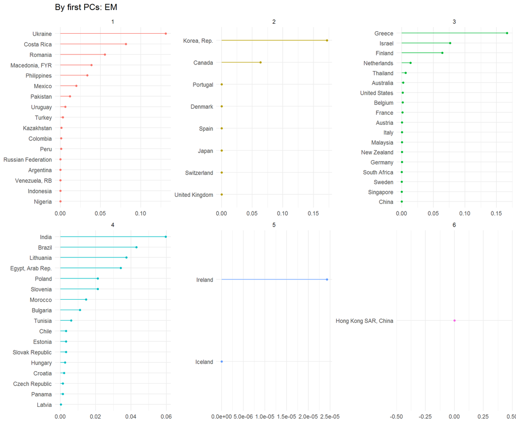

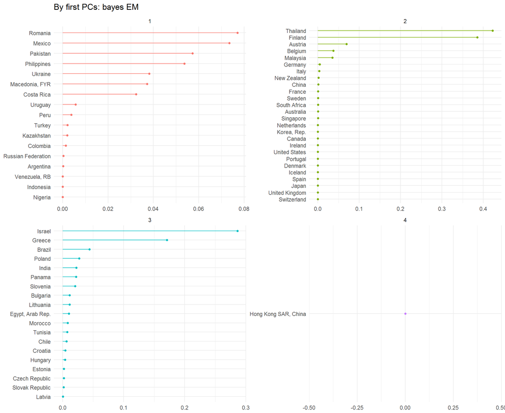